# Wizualizacja danych

## Python

### plotly + dash

*dr Bogna Zacny*  
Katedra Inżynierii Wiedzy  
Wydział Informatyki i Komunikacji  
Uniwersystet Ekonomiczny w Katowiacach

# plotly

biblioteka do tworzenia interaktywnych wykresów

Oficjalna [strona](https://plotly.com/python/) biblioteki

```python
pip install plotly
```

## plotly.graph_objects

```python
import plotly.graph_objects as go
```

- moduł `plotly.graph_objects` to najważniejszy moduł, który zawiera wszystkie definicje klas obiektów składających się na wyświetlane wykresy
  - `Figure`
    - `Data`
    - `Layout`
- wszystkie funkcje w `plotly.express`, są zbudowane w oparciu o obiekty klasy `plotly.graph_objects.Figure` i każda zwraca jej instancje

Oficjalna [strona](https://plotly.com/python/graph-objects/) modułu

[API](https://plotly.com/python-api-reference/generated/plotly.graph_objects.Figure.html)

## plotly.graph_objects

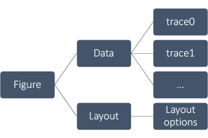

Parametr **`data`** jest obiektem typu `lista`. Jest to lista wszystkich `traces`, które mają być wyświtlone na wykresie.

**`trace`** to określenie zbioru danych (i metadanych), które mają zostać wykreślone. Obiekt typu `trace` nazwany jest zgodnie z tym, jak dane mają być wyświetlane na powierzchni kreślenia (`scatter`, `bar`, `pie`, `heatmap` itd).

## plotly.express

```python
import plotly.express as px
```

- Moduł `plotly.express`:
  - oferuje bibliotekę różnorodnych interaktywnych wykresów
  - wprowadzając wysokopoziomowy interface do szybkiego generowania wykresów
  - zapewniając jednocześnie możliwość ich parametryzacji
  - jest modułem zalecanym do ropoczęcia pracy z biblioteką `plotly`

Oficjalna [strona](https://plotly.com/python/plotly-express/) API modułu

[API](https://plotly.com/python-api-reference/plotly.express.html)

```python
import plotly.express as px

fig = px.pie(values = [16,15,19], names = ['a','b','c'])
type(fig)
```

# `Figure` (plotly.express)

```python
import pandas as pd

sprzedaz_dl = pd.DataFrame({'Miasto': ['Katowice', 'Kraków', 'Wrocław'] * 2,
                           'Produkty': ['Monitor21'] * 3 + ['Monitor24'] * 3,
                           'Sprzedaż': [2, 7, 3, 12, 7, 13]})

fig = px.bar(sprzedaz_dl, x = 'Produkty', y = 'Sprzedaż')
fig.show()
```

## `traces`

```python
fig = px.bar(sprzedaz_dl, x = 'Produkty', y = 'Sprzedaż', color = 'Miasto')

# fig.update_traces(text = ['21', '24'])
# fig.for_each_trace(lambda a: a.update(text=a.name))

fig.show()
```

## `layout`

```python
# fig = px.bar(sprzedaz_dl, x = 'Produkty', y = 'Sprzedaż', color = 'Miasto')

fig.update_layout(
    title = "Sprzedaż monitorów w miastach",
    xaxis_title = 'Rozmiar monitora', yaxis_title = 'Wielkość sprzedaży',
    yaxis = dict(
        tickmode = 'array',
        tickvals = [10, 20, 30],
        ticktext = ['10', '20', '30'],
        tickfont=dict(family='Calibri', color='darkred', size=25)
    ),
    showlegend=False
)

fig.update_xaxes(
    showgrid=False,
    ticks="outside",
    tickson="boundaries",
    ticklen=20,
    categoryorder = "sum descending"
)

fig.show()
```

# Themes

Dostępnych jest kilka gotowych [schematów](https://plotly.com/python/templates/) wyglądu wykresu

```python
import plotly.io as pio
pio.templates
```

```python
px.bar(sprzedaz_dl,
       x = 'Produkty', y = 'Sprzedaż', color = 'Miasto',
       template = 'simple_white')
```

# Palety kolorów

Dostępnych jest wiele wbudowanych palet kolorów dla

- [cech iloścowych](https://plotly.com/python/builtin-colorscales/)
- [cech jakoścowych](https://plotly.com/python/discrete-color/)

```python
print(px.colors.named_colorscales()[:10])
```

```python
fig = px.colors.sequential.swatches() #_continuous
# fig = px.colors.diverging.swatches() #_continuous
# fig = px.colors.cyclical.swatches() #_continuous
# fig = px.colors.qualitative.swatches()
fig.show()
```

# Zapisanie interaktywnego wykresu

```python
fig = px.bar(sprzedaz_dl,
       x = 'Produkty', y = 'Sprzedaż', color = 'Miasto',
       template = 'simple_white')
fig.write_html("bar.html")
```

# `Figure` (plotly.graph_objects)

```python
import plotly.graph_objects as go

fig = go.Figure(
    data=[go.Pie(values = [16,15,19], labels = ['a','b','c'])])

type(fig)
```

```python
fig.show()
```

```python
print(fig)
```

## Składanie `traces`

```python
# sprzedaz_dl = pd.DataFrame({'Miasto': ['Katowice', 'Kraków', 'Wrocław'] * 2,
#                            'Produkty': ['Monitor21'] * 3 + ['Monitor24'] * 3,
#                            'Sprzedaż': [2, 7, 3, 12, 7, 13]})

fig = go.Figure(
    data=[
        go.Bar(name='Katowice', x=sprzedaz_dl[sprzedaz_dl.Miasto=='Katowice'].Produkty, y=sprzedaz_dl[sprzedaz_dl.Miasto=='Katowice'].Sprzedaż),
        go.Bar(name='Kraków', x=sprzedaz_dl[sprzedaz_dl.Miasto=='Kraków'].Produkty, y=sprzedaz_dl[sprzedaz_dl.Miasto=='Kraków'].Sprzedaż),
        go.Bar(name='Wrocław', x=sprzedaz_dl[sprzedaz_dl.Miasto=='Wrocław'].Produkty, y=sprzedaz_dl[sprzedaz_dl.Miasto=='Wrocław'].Sprzedaż)
    ]
)

fig.update_layout(barmode='stack')
fig.show()
```

## Przykład (1)

```python
fig = px.pie(values = [16,15,19], names = ['a','b','c'],
             hole = 0.4,
             color_discrete_sequence=px.colors.qualitative.Dark2) # ['#AA3939', '#226666', '#7B9F35']

fig.update(layout_showlegend=False)

# fig.update_traces(textinfo = 'label+percent')
# fig.update_traces(textinfo = 'none')
fig.update_traces(text = ['coś' for _ in range(3)], textinfo = 'text')

fig.show()
```

## Przykład (2)

```python
sprzedaz_sz = pd.DataFrame({'Miasto': ['Katowice', 'Kraków', 'Wrocław'],
                           'Monitor21': [2, 7, 3],
                           'Monitor24': [12, 7, 13]})

# px.bar(sprzedaz_sz, x='Miasto', y = 'Monitor21')
# px.bar(sprzedaz_sz, x='Miasto', y = ['Monitor21', 'Monitor24'])

fig = px.bar(sprzedaz_sz, x='Miasto', y = ['Monitor21', 'Monitor24'], barmode = 'group') # relative
fig.update_layout(title = "Rozkład sprzedaży monitorów w miastach", yaxis_title = 'Wielkość sprzedaży',
                 legend_title_text='Produkty')
```

# Dash

`Dash` to platforma typu *open-source* do tworzenia aplikacji analitycznych, niewymagająca obsługi `HTML`, `CSS`, `JavaScript`, ściśle zintegrowana z biblioteką graficzną `Plotly`.

Oficjalna [strona](https://plotly.com/dash/) biblioteki

[User Guide](https://dash.plotly.com/)

#### Instalacja

```python
pip install dash
```

```python
conda install dash
```

> gdy pracujesz w [Colaboratory](https://colab.research.google.com/) należy dodatkowo zainstalować

```python
pip install jupyter-dash
```

## Składnia skryptu

Aplikacji z interaktywnym wykresem

```python
import plotly.graph_objects as go # lub plotly.express as px
fig = go.Figure() # lub którykolwiek Plotly Express function np. px.bar(...)
# fig.add_trace( ... )
# fig.update_layout( ... )

import dash
import dash_core_components as dcc
import dash_html_components as html

app = dash.Dash()
app.layout = html.Div([
    dcc.Graph(figure=fig)
])

app.run_server(debug=True, use_reloader=False)
# use_reloader=False - jeżeli z Jupytera
```

## Przykład (1)

```python
# !pip install dash

# !pip install jupyter-dash
```

```python
import dash
import dash_core_components as dcc
import dash_html_components as html
```

```python
import numpy as np

from jupyter_dash import JupyterDash

x = list(range(1,101))
y2 = np.log2(x)
y10 = np.log10(x)

fig = go.Figure(
    data=[
        go.Scatter(name = 'log2', x = x, y = y2),
        go.Scatter(name = 'log10', x = x, y = y10)]
)

# app = dash.Dash()
app = JupyterDash(__name__)
app.layout = html.Div([
    html.H1('Wykres logarytmów'),
    html.P('Prezentacja transformacji logarytmicznej przy podstawie 2 i 10'),
    dcc.Graph(figure=fig),
])

# app.run_server(debug=True, use_reloader=False)
app.run_server(mode='inline')
```

## Przykład (2)

```python
fig = go.Figure(
    data=[
        go.Scatter(name = 'log2', x = x, y = y2),
        go.Scatter(name = 'log10', x = x, y = y10)]
)

app = dash.Dash()
app.layout = html.Div([
    html.H1(children = 'Wykres logarytmów',
           style = {
               'textAlign' : 'center',
               'color' : '#ff0000'
           }),
    html.P('Prezentacja transformacji logarytmicznej przy podstawie 2 i 10'),
    dcc.Graph(figure=fig),
])

# app.run_server(debug=True, use_reloader=False)
```

## Składnia skryptu

Aplikacji z dynamicznymi elementami

```python
from dash.dependencies import Input, Output

# app = dash.Dash()
app = JupyterDash(__name__)

app.layout = html.Div([
    # komponent, który przyjmuje dane użytkownika
    dcc.Input(id='my-input', value='wpisz coś', type='text'),

    html.P(),

    # komponent, który wyświetla wynik
    html.Div(id='my-output')
])


# obiekt, który wiąże dane użytkownika z fukcją (która je przetwarza)
# i przekazuje wynik
@app.callback(
    Output(component_id='my-output', component_property='children'),
    Input(component_id='my-input', component_property='value'))


# fukcja, która przetwarza dane użytkownika i zwraca wynik
def update_output_div(input_value):

    output_value = f'Wpisałeś: {input_value}'
    return output_value


# app.run_server(debug=True, use_reloader=False)
app.run_server(mode='inline')
```

## Przykład (3)

```python
df = px.data.tips()

# app = dash.Dash()
app = JupyterDash(__name__)


app.layout = html.Div([
    html.H4('Napiwki w dniach tygodnia'),
    html.Br(),
    html.Br(),

    html.Label('Wybierz dzień'),
    html.Br(),

    dcc.Dropdown(
        id="lista",
        options=[{'label': "piątek", 'value': "Fri"},
                 {'label': "sobota", 'value': "Sat"},
                 {'label': "niedziela", 'value': "Sun"}],
        value="Fri",
        clearable=False,
    ),
    dcc.Graph(id="wykres"),
])


@app.callback(
    Output("wykres", "figure"),
    Input("lista", "value"))

def update_bar_chart(day):

    mask = df["day"] == day
    fig = px.bar(df[mask], x="sex", y="total_bill",
                 color="smoker", barmode="group")
    return fig


# app.run_server(debug=True, use_reloader=False)
app.run_server(mode='inline')
```